# 2. час: Записивање и приказивање низова података

На овом часу ћеш научити:

1. како да се крећеш кроз Џупајтер радну свеску;
2. како се записују низови података; и
3. један начин за приказивање низова података.

## 2.1. Још мало о Џупајтер радној свесци

Џупајтер радна свеска се састоји из низа ћелија, а свака ћелија може да садржи текст, математички израз или низ Пајтон наредби. Низ икона при врху стране ти омогућује да бараташ ћелијама Џупајтер радне свеске на разне начине.

Дугме **Run** смо већ користили. Погледајмо сада чему служе још четири дугмета:

[figure not shown]

- Клик на дугме које личи на дискету (прва слева) ће снимити радну свеску.
- Клик на дугме са знаком **+** ће додати нову ћелију испод активне ћелије. (Ћелију активираш тако што кликнеш на њу; активна ћелија има ***зелени*** или ***плави*** оквир.)
- Стрелице на горе и на доле померају радну ћелију за једно место горе или доле.

На пример, да бисмо додали нову ћелију испод ове кликнућемо на ову ћелију, па на дугме са знаком **+**. Онда у новој ћелији можемо нешто да израчунамо, рецимо, вредност израза $1 + \frac 12 + \frac 13 + \frac 14 + \frac 15 + \frac 16 + \frac 17$:

```python
1 + 1/2 + 1/3 + 1/4 + 1/5 + 1/6 + 1/7
```

```
2.5928571428571425
```

## 2.2. Записивање низова података

Низови података се у Пајтону записују унутар угластих заграда. На пример, оцене неког ученика из једног предмета могу да се запишу као низ овако:

```python
ocene = [2, 4, 5, 3, 5]
```

Систем није вратио никакав излаз, наравно. Он је само констатовао да променљива `ocene` сада садржи низ који се састоји од пет бројева. Да бисмо се уверили да је то тако, затражићемо од система да израчуна следећи израз:

```python
ocene
```

```
[2, 4, 5, 3, 5]
```

Могуће је радити и са низовима стрингова:

```python
predmeti = ["математика", "српски", "ликовно", "историја", "физичко"]
```

Систем ни овај пут није вратио никакав излаз, већ је само запамтио да променљива `predmeti` сада садржи низ од пет стрингова (имена предмета). Ево садржаја променљиве `predmeti`:

```python
predmeti
```

```
['математика', 'српски', 'ликовно', 'историја', 'физичко']
```

Дужину низа можемо добити позивом уграђене функције `len` (што је скраћеница енглеске речи *length* која значи "дужина"):

```python
len(predmeti)
```

```
5
```

## 2.3. Приказивање низова података

Сјеница је један од најхладнијих градова у Србији. У ћелији испод налазе се три низа података: списак имена месеци и потом максималне и минималне температуре по месецима које су забележене у Сјеници у периоду 1981-2010. године. (Подаци су преузети са сајта Републичког хидрометеоролошког завода и доступни су на адреси http://www.hidmet.gov.rs/latin/meteorologija/stanica_sr.php?moss_id=13369)

```python
meseci =               ["Јан", "Феб", "Мар", "Апр", "Мај", "Јун", "Јул", "Авг", "Сеп", "Окт", "Нов", "Дец"]
SjenicaMaxPoMesecima = [ 14.0,  19.4,  21.9,  24.3,  28.8,  31.5,  33.5,  32.8,  29.7,  26.5,  20.2,  18.0]
SjenicaMinPoMesecima = [-35.6, -31.0, -25.0,  -8.3,  -6.4,  -3.7,  -0.4,  -1.3,  -9.3, -10.7, -26.2, -29.6]
```

Желели бисмо да прикажемо ове податке у виду графикона (да их *визуелизујемо*) зато што људи најлакше и најбрже обрађују визуелне податке. (Вероватно знаш за изреку да *једна слика вреди више од хиљаду речи*.)

Пајтон има разне библиотеке за визуелизацију података, а ми ћемо користити библиотеку која се зове `matplotlib.pyplot`. Пошто је ово име веома дугачко и компликовано и пошто ће нам требати много функција из те библиотеке нећемо увозити функције једну по једну већ ћемо увести целу библиотеку и при томе јој дати краће име (такорећи, надимак) `plt`. (Енглеска реч *plot* значи "исцртати", а `plt` је скраћено од `plot`.)

```python
import matplotlib.pyplot as plt
```

Сада су нам све функције из ове библиотеке доступне и можемо кренути са цртањем графикона. Најједноставнији графикон се може добити овако:

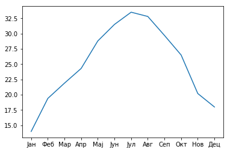

```python
plt.plot(meseci, SjenicaMaxPoMesecima)
plt.show()
plt.close()
```

Функција `plot(meseci, SjenicaMaxPoMesecima)` каже систему да треба нацртати графикон коме су на хоризонталну осу ($x$-оса) нанети подаци из низа `meseci`, а на вертикалну осу ($y$-оса) подаци из низа `SjenicaMaxPoMesecima`. Функција `show` потом приказује графикон. (Енглеска реч *plot* значи "исцртати", а енглеска реч *show* значи "приказати".) Коначно, функција `close` завршава рад на графикону (енглеска реч *close* значи "затвори").

Пошто нисмо увозили појединачне функције већ смо целу библиотеку увезли под надимком `plt`, функције `plot` и `show` морамо да позовемо "пуним презименом и именом": `plt.plot` и `plt.show`.

У наредном кораку ћемо графикону додати наслов користећи функцију `title` (енглеска реч *title* значи "наслов"):

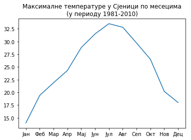

```python
plt.plot(meseci, SjenicaMaxPoMesecima)
plt.title("Максималне температуре у Сјеници по месецима\n(у периоду 1981-2010)")
plt.show()
plt.close()
```

Можемо ставити ознаку и на вертикалну осу да бисмо нагласили да се ради о температурама у Целзијусима. За то користимо функцију `ylabel` ("ознака на $y$-оси"; енглеска реч *label* значи "ознака"):

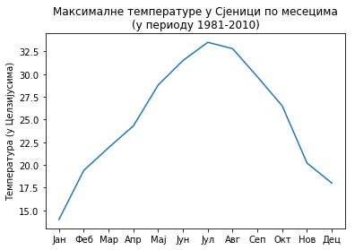

```python
plt.plot(meseci, SjenicaMaxPoMesecima)
plt.title("Максималне температуре у Сјеници по месецима\n(у периоду 1981-2010)")
plt.ylabel("Температура (у Целзијусима)")
plt.show()
plt.close()
```

На крају ћемо на исти графикон додати и податке за минималне температуре по месецима (и променити наслов графикона, наравно):

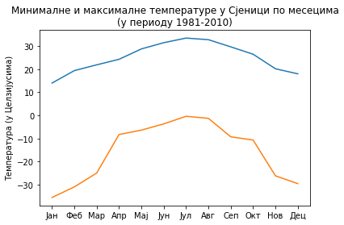

```python
plt.plot(meseci, SjenicaMaxPoMesecima)
plt.plot(meseci, SjenicaMinPoMesecima)
plt.title("Минималне и максималне температуре у Сјеници по месецима\n(у периоду 1981-2010)")
plt.ylabel("Температура (у Целзијусима)")
plt.show()
plt.close()
```

Да закључимо: функцијама `plot`, `title` и `ylabel` додајемо податке на графикон, и тек када смо унели све податке које желимо да имамо на графикону цртамо графикон позивом функције `show`.

## 2.4. Задаци

**Задатак 1.** Биолози су до данас описали око два милиона врта живих бића. Сва она су подељена у пет царстава и приближан број врста живих бића по царствима је дат следећом табелом:

| Царство | Број врста |
| --- | --- |
| Животиње | 1.400.000 |
| Биљке | 290.000 |
| Гљиве | 100.000 |
| Протисти | 200.000 |
| Монере | 10.000 |

Прикажи ове податке графиконом.

**Задатак 2.** У наредној ћелији дати су подаци о тежини (у килограмима) и дужини/висини (у центиметрима) једног дечака од његовог шестог месеца па до његових 6,5 година. Прикажи ове податке графиконом.

```python
# изврши ову ћелију
merenja   = ["6 мес", "1,5 год", "2,5 год", "3,5 год", "4,5 год", "5,5 год", "6,5 год"]
masaKG    = [5.9,     11.5,      14.8,      20.5,      22.0,      24.2,      29.0     ]
visinaCM  = [62.0,    84.0,      97.0,      115.0,     122.5,     131.5,     135.0    ]
```

**Задатак 3.** У следећој ћелији налазе се подаци преузети са сајта Републичког завода за статистику (http://www.stat.gov.rs/) који показују како се у периоду од 2008. до 2017. године мењао проценат броја становника Србије који никада нису користили рачунар, проценат броја становника Србије који редовно користе рачунар и проценат броја становника Србије који понекад користе рачунар. Прикажи ове податке графиконом.

```python
# изврши ову ћелију
godina                    = [2008, 2009, 2010, 2011, 2012, 2013, 2014, 2015, 2016, 2017]
procenatNeKoristiRac      = [48,   44.7, 43.7, 40.1, 38.9, 36.6, 29.7, 28.7, 27.2, 26.1]
procenatRedovnoKoristiRac = [45.5, 49.3, 50.8, 54.3, 55,   56.9, 62.5, 65.8, 67.2, 67.7]
procenatPonekadKoristiRac = [6.5,  6.0,  5.5,  5.6,  6.1,  6.5,  7.8,  5.5,  5.6,  6.2]
```

**Задатак 4.** На сајту Републичког хидрометеоролошког завода (http://www.hidmet.gov.rs/) у менију са леве стране кликни на "Метеорологија", па "Климатологија", па на "Нормале". Потом у списку станица за осматрање који се појавио одабери станицу најближу твојој школи, преузми најниже и највише температуре у периоду 1981-2010 (редови "Апсолутни максимум" и "Апсолутни минимум") и прикажи те податке на једном графикону. *Ученици из Сјенице нека одаберу град по жељи!* Задатак реши тако што ћеш испод ове ћелије додати једну или више нових ћелија у које ћеш унети одговарајуће Пајтон команде.